# Meta-Analysis of the Relation between Bilingualism and Executive Functioning in Adults

UV9216 General Course in Meta-Analysis

Data Example: Lehtonen et al. (2018) Psychological Bulletin

# Context

This is an analytic example of a meta-analysis with multiple effect sizes per study and sample. The data were extracted from Lehtonen et al. (2018), *Psychological Bulletin*, DOI:10.1037/bul0000142. This meta-analysis was concerned with the link between bilingualism and executive functioning (EF) in adult samples and compared performance on EF tests between bilingual and monolingual participants across studies.

*Note:* Some key analytic elements are not presented here, including p-curve estimation, forest plots, identifying influential effect sizes, outcome-specific analyses, and additional sensitivity analyses (e.g., Bayesian or aggregated meta-analysis).

# Preparation and data input

## Install and load relevant `R` packages

```r
# Install R packages (if needed)
# install.packages("pacman")
library(pacman)

# Load packages
pacman::p_load(metafor,
               ggplot2,
               robumeta,
               metaSEM,
               clubSandwich,
               MAd,
               remotes)

# Additional packages
# dmetar: https://dmetar.protectlab.org/
# remotes::install_github("MathiasHarrer/dmetar")
library(dmetar)
```

## Data input and preparation

The data derived from the primary studies are stored in a separate csv-file. They are specific to the study category. We read them in here and name them `lehtonen18`

```r
# Read in the data and define them as an object
lehtonen18 <- read.csv2("Lehtonen2018.csv", header = TRUE, dec = ',')
head(lehtonen18, 10)
```

```
##                  StudyName Sample     Domain StudyType             Task
## 1        Lee & Chan (2000)      1 Inhibition      Peer           Stroop
## 2   Rosselli et al. (2000)      1    Fluency      Peer Category Fluency
## 3   Rosselli et al. (2000)      1    Fluency      Peer   Letter Fluency
## 4     Gollan et al. (2002)      1    Fluency      Peer Category Fluency
## 5     Gollan et al. (2002)      1    Fluency      Peer   Letter Fluency
## 6   Rosselli et al. (2002)      1 Inhibition      Peer           Stroop
## 7   Rosselli et al. (2002)      1 Monitoring      Peer           Stroop
## 8            Boutla (2003)      1         WM      Peer   Simple Span FW
## 9  Bialystok et al. (2004)      1 Inhibition      Peer            Simon
## 10 Bialystok et al. (2004)      1 Monitoring      Peer            Simon
##    Stimulus MeasureType M.Mono SD.Mono N.Mono M.Biling SD.Biling N.Biling     g
## 1         V          RT   8.04    4.38     35     9.25      4.87       50 -0.26
## 2         V           O  26.40    7.60     19    31.70      7.20       18 -0.70
## 3         V           O  35.20   13.80     19    34.90     11.20       18  0.02
```

[output cut: 18 more lines]

```r
# Create IDs for the relevant study groups (levels)
## Effect size ID (ESID)
lehtonen18$ESID <- seq_len(nrow(lehtonen18))

## Study ID (StudyID)
lehtonen18$StudyID <- as.numeric(factor(lehtonen18$StudyName))

## Sample ID (SampleID)
lehtonen18$SampleID <- 10000*lehtonen18$StudyID + lehtonen18$Sample

## Task ID (TaskID)
lehtonen18$TaskID <- as.numeric(factor(lehtonen18$Task))

# Add the standard error to the data set
lehtonen18$SEg <- sqrt(lehtonen18$vg)

# Transform some moderator variables
## Stimulus
## Verbal coded as 1 and non-verbal as 0
lehtonen18$Stimulus.binary <- as.numeric(factor(lehtonen18$Stimulus))-1

## Study type
## Peer coded as 1 and other as 0
lehtonen18$StudyType.binary <- as.numeric(factor(lehtonen18$StudyType))-1
```

Key numbers for describing the data are the number of effect sizes, studies, samples, and tasks. The data exhibit some hierarchical structure with multiple effect sizes per sample and study. Effect sizes are nested in samples, samples are nested in studies, and effect sizes are nested in tasks.

```r
## Number of effect sizes (k)
length(lehtonen18$ESID)
```

```
## [1] 891
```

```r
## Number of effect sizes per study
table(lehtonen18$StudyID)
```

```
##
##   1   2   3   4   5   6   7   8   9  10  11  12  13  14  15  16  17  18  19  20
##   2   2   3   5   7   3   6   3  16   4   1  14  16   2   4   6   8   7   1   2
##  21  22  23  24  25  26  27  28  29  30  31  32  33  34  35  36  37  38  39  40
##   6  11   2   9   8   2   1   4   1   3   1   5  12   2   4   5   4   4   1   4
##  41  42  43  44  45  46  47  48  49  50  51  52  53  54  55  56  57  58  59  60
##   9   6   1  15   4   6   4   7   2   1   4   2  12   2   2   6   2   7   1   2
##  61  62  63  64  65  66  67  68  69  70  71  72  73  74  75  76  77  78  79  80
##   2   6   2   8   7   4   8  12   2   3  12   4   6   3  40  12  13   1  10   4
##  81  82  83  84  85  86  87  88  89  90  91  92  93  94  95  96  97  98  99 100
##   4  24   1   6   8   8   2   4   3   4   2   8   1   1   2   8   6   4  12  15
## 101 102 103 104 105 106 107 108 109 110 111 112 113 114 115 116 117 118 119 120
##   7   8   8   6   3   2   6  12   4   2   2   3   2   1  14   2   2  15   8   2
## 121 122 123 124 125 126 127 128 129 130 131 132 133 134 135 136 137 138 139 140
##  10   4   4   7   2   2   2   6   6   2   4   5   5   8   8   1  14  18   6   1
## 141 142 143 144 145 146 147 148 149 150 151 152
##   6  10  18   3  10   2  16   3   4   2   3  12
```

```r
## Number of studies (n)
length(table(lehtonen18$StudyID))
```

```
## [1] 152
```

```r
## Number of samples (m)
length(table(lehtonen18$SampleID))
```

```
## [1] 273
```

```r
## Number of tasks (t)
length(table(lehtonen18$TaskID))
```

```
## [1] 30
```

# Meta-analysis ignoring the hierarchical data structure (`IGNORE`)

The following model represents a standard random-effects model that quantifies variation between effect sizes.

## Model specification and estimation

```r
# Model estimation
## Key elements: Effect size g, sampling variance vg, data set
REM1ig <- rma.uni(g,
                  vg,
                  data = lehtonen18,
                  method = "REML")

# Summarize the results
summary(REM1ig, digits=4)
```

```
##
## Random-Effects Model (k = 891; tau^2 estimator: REML)
##
##    logLik   deviance        AIC        BIC       AICc
## -780.1736  1560.3472  1564.3472  1573.9297  1564.3608
##
## tau^2 (estimated amount of total heterogeneity): 0.2072 (SE = 0.0137)
## tau (square root of estimated tau^2 value):      0.4551
## I^2 (total heterogeneity / total variability):   75.30%
## H^2 (total variability / sampling variability):  4.05
##
## Test for Heterogeneity:
## Q(df = 890) = 3239.5972, p-val < .0001
##
## Model Results:
##
## estimate      se    zval    pval   ci.lb   ci.ub
##   0.0760  0.0181  4.1987  <.0001  0.0405  0.1114  ***
##
## ---
## Signif. codes:  0 '***' 0.001 '**' 0.01 '*' 0.05 '.' 0.1 ' ' 1
```

```r
# Alternative model specification and estimation
# Best specification to compare to multilevel models.
REM2 <- rma.mv(g,
               vg,
               data = lehtonen18,
               method = "REML",
               tdist = TRUE,
               test = "t",
               random = list(~ 1 | ESID))

summary(REM2)
```

```
##
## Multivariate Meta-Analysis Model (k = 891; method: REML)
##
##    logLik   Deviance        AIC        BIC       AICc
## -780.1736  1560.3472  1564.3472  1573.9297  1564.3608
##
## Variance Components:
##
##             estim    sqrt  nlvls  fixed  factor
## sigma^2    0.2072  0.4551    891     no    ESID
##
## Test for Heterogeneity:
## Q(df = 890) = 3239.5972, p-val < .0001
##
## Model Results:
##
## estimate      se    tval   df    pval   ci.lb   ci.ub
##   0.0760  0.0181  4.1987  890  <.0001  0.0405  0.1115  ***
##
## ---
## Signif. codes:  0 '***' 0.001 '**' 0.01 '*' 0.05 '.' 0.1 ' ' 1
```

```r
# Call for the 95% confidence intervals
confint(REM2, digits=4)
```

```
##
##         estimate  ci.lb  ci.ub
## sigma^2   0.2072 0.1798 0.2383
## sigma     0.4551 0.4241 0.4882
```

```r
# Estimation of overall and level-specific I-squared
k <- nrow(lehtonen18)
W <- diag(1/lehtonen18$vg)
X <- model.matrix(REM2)
P <- W - W %*% X %*% solve(t(X) %*% W %*% X) %*% t(X) %*% W
# Overall I-squared
100 * sum(REM2$sigma2) / (sum(REM2$sigma2) + (REM2$k-REM2$p)/sum(diag(P)))
```

```
## [1] 75.30218
```

## Some useful plots, statistics, and tests

```r
# Fit statistics
fitstats.rma(REM1ig)
```

```
##                REML
## logLik:   -780.1736
## deviance: 1560.3472
## AIC:      1564.3472
## BIC:      1573.9297
## AICc:     1564.3608
```

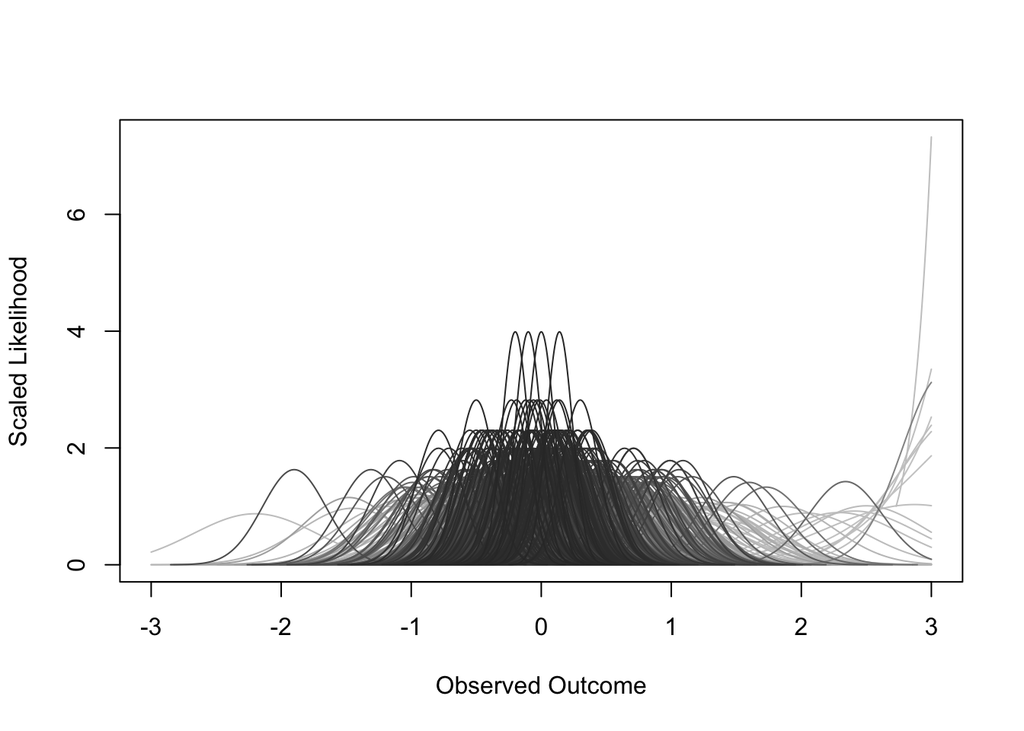

```r
# Likelihood plot
llplot(measure = "GEN",
       yi=g,
       vi=vg,
       data = lehtonen18,
       lwd = 1,
       refline = NA,
       xlim = c(-3,3))
```

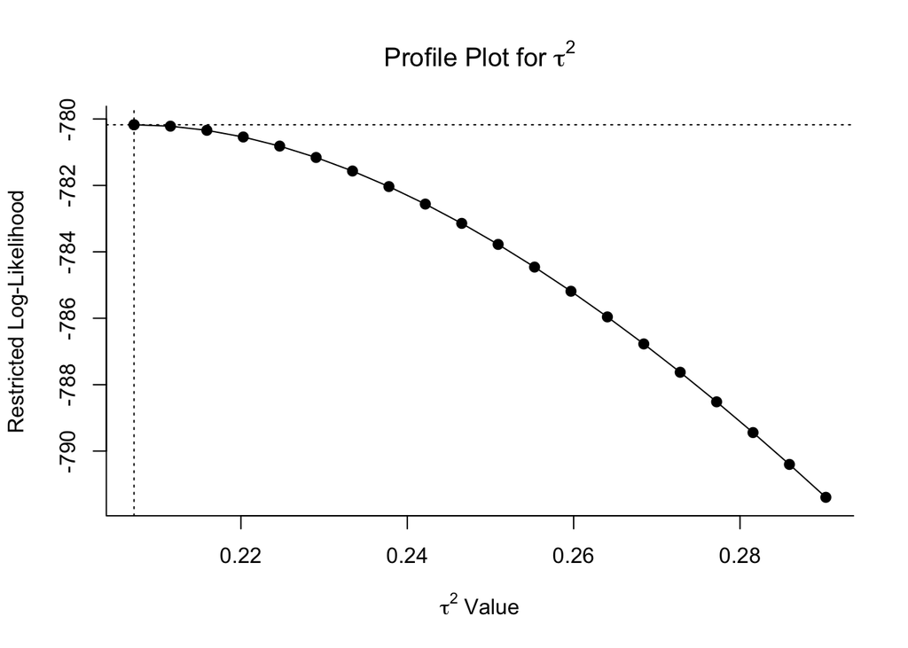

```r
# Profile plot
profile.rma.uni(REM1ig)
```

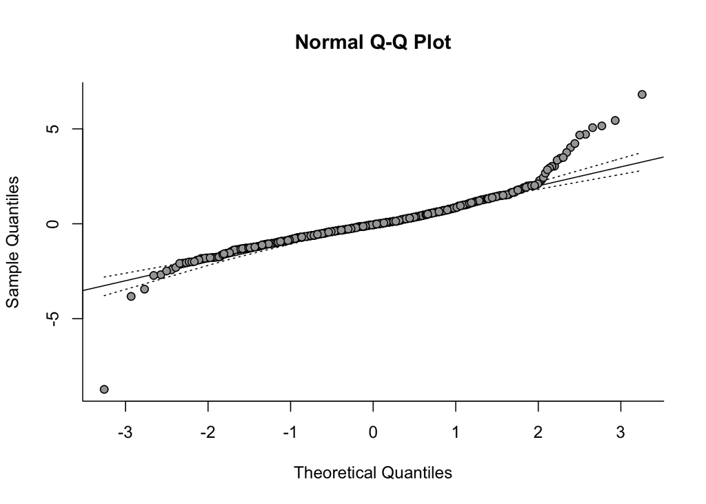

```r
# Normal QQ plots
qqnorm.rma.uni(REM1ig)
```

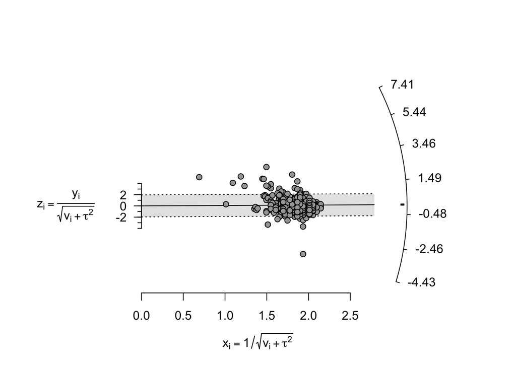

```r
# Radial plot
radial.rma(REM1ig)
```

# Meta-analysis aggregating to the hierarchical data structure (`AGGREGATE`)

Using Borenstein et al.’s (2009) method, the multiple effect sizes within one study can be averaged, and the resultant sampling variances combined. However, some assumption on the correlation between the different outcomes is needed.

## Combine the effect sizes within studies

```r
# Aggregate the effect sizes via Borenstein's method
# Use the study ID for aggregation
leh18agg <- agg(id = StudyID,
                es = g,
                var = vg,
                cor = 0.5,
                method = "BHHR",
                data = lehtonen18)

# Inspect the new data set
head(leh18agg)
```

```
##    id       es        var
## 1  78 -0.26000 0.05000000
## 2 116 -0.34000 0.08622281
## 3  54 -0.63000 0.05250000
## 4 117 -0.31000 0.08250000
## 5  27  0.78000 0.14000000
## 6   9  1.68125 0.13667369
```

```r
# Aggregate the effect sizes via Viechtbauer's method
# Source: https://wviechtb.github.io/metafor/reference/aggregate.escalc.html
# Use the study ID for aggregation
# Step 0: Change the format of the effect sizes into an escalc() object
leh18escalc <- metafor::escalc(yi = g,
                               vi = vg,
                               data = lehtonen18)
class(leh18escalc)
```

```
## [1] "escalc"     "data.frame"
```

```r
# Step 1: Estimate the sampling covariance matrix
Vagg <- metafor::vcalc(vg,
                       cluster = StudyID,
                       obs = ESID,
                       data = leh18escalc,
                       rho = 0.5)

# Step 2: Aggregate the effect sizes
leh18agg2 <- metafor::aggregate.escalc(leh18escalc,
                                       cluster = StudyID,
                                       V = Vagg,
                                       struc = "CS")

# Inspect the new effect sizes and sampling variances
lehtonen18agg <- cbind.data.frame(leh18agg2$StudyID,
                                  leh18agg2$yi,
                                  leh18agg2$vi)

colnames(lehtonen18agg) <- c("StudyID", "yi", "vi")
head(lehtonen18agg)
```

```
##   StudyID         yi         vi
## 1      78 -0.2600000 0.05000000
## 2     116 -0.3087252 0.08600563
## 3      54 -0.6300000 0.05250000
## 4     117 -0.3100000 0.08250000
## 5      27  0.7800000 0.14000000
## 6       9 -0.8451859 0.02837452
```

## Baseline model

### Model 1: Random-effects model (REM)

```r
# Model estimation
REMagg <- rma.uni(es,
                  var,
                  data = leh18agg,
                  method = "REML")

# Summarize the results
summary(REMagg, digits=4)
```

```
##
## Random-Effects Model (k = 152; tau^2 estimator: REML)
##
##    logLik   deviance        AIC        BIC       AICc
## -102.2473   204.4947   208.4947   214.5292   208.5758
##
## tau^2 (estimated amount of total heterogeneity): 0.1434 (SE = 0.0228)
## tau (square root of estimated tau^2 value):      0.3787
## I^2 (total heterogeneity / total variability):   76.42%
## H^2 (total variability / sampling variability):  4.24
##
## Test for Heterogeneity:
## Q(df = 151) = 583.0440, p-val < .0001
##
## Model Results:
##
## estimate      se    zval    pval    ci.lb   ci.ub
##   0.0599  0.0363  1.6465  0.0997  -0.0114  0.1311  .
##
## ---
## Signif. codes:  0 '***' 0.001 '**' 0.01 '*' 0.05 '.' 0.1 ' ' 1
```

```r
# Call for the 95% confidence intervals
confint(REMagg, digits=4)
```

```
##
##        estimate   ci.lb   ci.ub
## tau^2    0.1434  0.1202  0.2356
## tau      0.3787  0.3467  0.4854
## I^2(%)  76.4220 73.0959 84.1877
## H^2      4.2412  3.7169  6.3242
```

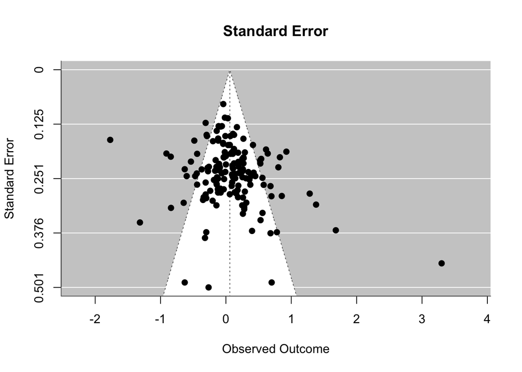

```r
# Funnel plot
funnel.rma(REMagg, main = "Standard Error")
```

```r
# For comparison: Viechtbauer's method
summary(rma.uni(yi, vi, data = lehtonen18agg, method = "REML"))
```

```
##
## Random-Effects Model (k = 152; tau^2 estimator: REML)
##
##   logLik  deviance       AIC       BIC      AICc
## -68.5126  137.0252  141.0252  147.0598  141.1063
##
## tau^2 (estimated amount of total heterogeneity): 0.0675 (SE = 0.0133)
## tau (square root of estimated tau^2 value):      0.2598
## I^2 (total heterogeneity / total variability):   62.45%
## H^2 (total variability / sampling variability):  2.66
##
## Test for Heterogeneity:
## Q(df = 151) = 395.0679, p-val < .0001
##
## Model Results:
##
## estimate      se    zval    pval    ci.lb   ci.ub
##   0.0326  0.0279  1.1651  0.2440  -0.0222  0.0873
##
## ---
## Signif. codes:  0 '***' 0.001 '**' 0.01 '*' 0.05 '.' 0.1 ' ' 1
```

### Model 2: Fixed-Effects Model (FEM)

```r
# Model estimation
FEMagg <- rma.uni(es,
                  var,
                  data = leh18agg,
                  method = "FE")

# Summarize the results
summary(FEMagg, digits=4)
```

```
##
## Fixed-Effects Model (k = 152)
##
##    logLik   deviance        AIC        BIC       AICc
## -208.6043   583.0440   419.2086   422.2325   419.2353
##
## I^2 (total heterogeneity / total variability):   74.10%
## H^2 (total variability / sampling variability):  3.86
##
## Test for Heterogeneity:
## Q(df = 151) = 583.0440, p-val < .0001
##
## Model Results:
##
## estimate      se    zval    pval    ci.lb   ci.ub
##   0.0195  0.0170  1.1433  0.2529  -0.0139  0.0528
##
## ---
## Signif. codes:  0 '***' 0.001 '**' 0.01 '*' 0.05 '.' 0.1 ' ' 1
```

### Model comparison: REM vs. FEM

```r
# Model comparison
anova(REMagg, FEMagg)
```

```
##
##         df      AIC      BIC     AICc    logLik      LRT   pval       QE  tau^2
## Full     2 208.4947 214.5292 208.5758 -102.2473                 583.0440 0.1434
## Reduced  1 420.4927 423.5100 420.5196 -209.2464 213.9980 <.0001 583.0440 0.0000
##             R^2
## Full
## Reduced 0.0000%
```

# Meta-analysis correcting for the hierarchical data structure (`CORRECT`)

## Robust variance estimation in `robumeta`

In the following models, we correct for the clustering of effect sizes in studies.

### Baseline Models

#### Assumption of hierarchical effects

```r
# Model estimation without a small-sample size correction
REM1corsh <- robu(g ~ 1,
                 data = lehtonen18,
                 studynum = StudyID,
                 var.eff.size = vg,
                 small = FALSE,
                 modelweights = "HIER")

# Summarize the results
print(REM1corsh)
```

```
## RVE: Hierarchical Effects Model
##
## Model: g ~ 1
##
## Number of clusters = 152
## Number of outcomes = 891 (min = 1 , mean = 5.86 , median = 4 , max = 40 )
## Omega.sq = 0.008930705
## Tau.sq = 0.1726971
##
##                Estimate StdErr t-value dfs P(|t|>) 95% CI.L 95% CI.U Sig
## 1 X.Intercept.   0.0742 0.0324    2.29 151  0.0236   0.0101    0.138  **
## ---
## Signif. codes: < .01 *** < .05 ** < .10 *
## ---
```

```r
##########
# Model estimation with a small-sample size correction
REM1corsh2 <- robu(g ~ 1,
                 data = lehtonen18,
                 studynum = StudyID,
                 var.eff.size = vg,
                 small = TRUE,
                 modelweights = "HIER")

# Summarize the results
print(REM1corsh2)
```

```
## RVE: Hierarchical Effects Model with Small-Sample Corrections
##
## Model: g ~ 1
##
## Number of clusters = 152
## Number of outcomes = 891 (min = 1 , mean = 5.86 , median = 4 , max = 40 )
## Omega.sq = 0.008930705
## Tau.sq = 0.1726971
##
##                Estimate StdErr t-value  dfs P(|t|>) 95% CI.L 95% CI.U Sig
## 1 X.Intercept.   0.0742 0.0325    2.28 80.7  0.0252  0.00946    0.139  **
## ---
## Signif. codes: < .01 *** < .05 ** < .10 *
## ---
## Note: If df < 4, do not trust the results
```

#### Assumption of correlated effects

```r
# Model estimation
REM1corsc <- robu(g ~ 1,
                 data = lehtonen18,
                 studynum = StudyID,
                 var.eff.size = vg,
                 small = TRUE,
                 modelweights = "CORR",
                 rho = 0.5)

# Summarize the results
print(REM1corsc)
```

```
## RVE: Correlated Effects Model with Small-Sample Corrections
##
## Model: g ~ 1
##
## Number of studies = 152
## Number of outcomes = 891 (min = 1 , mean = 5.86 , median = 4 , max = 40 )
## Rho = 0.5
## I.sq = 79.11383
## Tau.sq = 0.264414
##
##                Estimate StdErr t-value dfs P(|t|>) 95% CI.L 95% CI.U Sig
## 1 X.Intercept.   0.0581  0.037    1.57 149   0.118  -0.0149    0.131
## ---
## Signif. codes: < .01 *** < .05 ** < .10 *
## ---
## Note: If df < 4, do not trust the results
```

```r
# Sensitivity analyses
sensitivity(REM1corsc)
```

```
## RVE: Correlated Effects Model with Small-Sample Corrections
## Model: g ~ 1
##
## Sensitivity Analysis
##
##                           Rho = 0 Rho = 0.2 Rho = 0.4 Rho = 0.6 Rho = 0.8
##  X.Intercept. Coefficient 0.0581  0.0581    0.0581    0.0581    0.0581
##               Std. Error  0.0370  0.0370    0.0370    0.0370    0.0370
##  Tau.sq       Estimate    0.2643  0.2643    0.2644    0.2644    0.2645
##  Rho = 1
##  0.0581
##  0.0370
##  0.2646
```

*Note:* Sensitivity analyses must be conducted if the model is specified with a specific value of the correlation rho.

## Moderator analyses

This examples showcases the moderator analyses via meta-regression in `robumeta`, utilizing the hierarchical model specification without small-sample size corrections.

```r
# Model estimation without a small-sample size correction
MEM3corsh <- robu(g ~ Stimulus.binary + StudyType.binary,
                 data = lehtonen18,
                 studynum = StudyID,
                 var.eff.size = vg,
                 small = FALSE,
                 modelweights = "HIER")

# Summarize the results
print(MEM3corsh)
```

```
## RVE: Hierarchical Effects Model
##
## Model: g ~ Stimulus.binary + StudyType.binary
##
## Number of clusters = 152
## Number of outcomes = 891 (min = 1 , mean = 5.86 , median = 4 , max = 40 )
## Omega.sq = 0.004232031
## Tau.sq = 0.1745744
##
##                    Estimate StdErr t-value dfs  P(|t|>) 95% CI.L 95% CI.U Sig
## 1     X.Intercept.   0.1289 0.0574   2.245 149 0.026225   0.0155    0.242  **
## 2  Stimulus.binary  -0.1699 0.0501  -3.394 149 0.000883  -0.2688   -0.071 ***
## 3 StudyType.binary   0.0459 0.0682   0.673 149 0.502121  -0.0889    0.181
## ---
## Signif. codes: < .01 *** < .05 ** < .10 *
## ---
```

# Meta-analysis modeling the hierarchical and correlated effects (`MODEL`)

## Multilevel Meta-Analysis (MLMA)

The following models make explicit the variance components at each level of analysis. We assume that the effects are hierarchical.

### Three-level random-effects model with between-study variance

```r
# Model estimation
REM3st <- rma.mv(g,
                 vg,
                 data = lehtonen18,
                 method = "REML",
                 tdist = TRUE,
                 test = "t",
                 random = list(~ 1 | StudyID/ESID))

# Summary of the results
summary(REM3st)
```

```
##
## Multivariate Meta-Analysis Model (k = 891; method: REML)
##
##    logLik   Deviance        AIC        BIC       AICc
## -696.1839  1392.3678  1398.3678  1412.7415  1398.3949
##
## Variance Components:
##
##             estim    sqrt  nlvls  fixed        factor
## sigma^2.1  0.1237  0.3518    152     no       StudyID
## sigma^2.2  0.1159  0.3405    891     no  StudyID/ESID
##
## Test for Heterogeneity:
## Q(df = 890) = 3239.5972, p-val < .0001
##
## Model Results:
##
## estimate      se    tval   df    pval   ci.lb   ci.ub
##   0.0766  0.0343  2.2324  890  0.0258  0.0093  0.1439  *
##
## ---
## Signif. codes:  0 '***' 0.001 '**' 0.01 '*' 0.05 '.' 0.1 ' ' 1
```

```r
# Confidence intervals
#metafor::confint.rma.mv(REM3st)

# Cluster-robust standard errors
coef_test(REM3st, vcov = "CR2")
```

```
##    Coef. Estimate     SE t-stat d.f. (Satt) p-val (Satt) Sig.
##  intrcpt   0.0766 0.0343   2.23         142       0.0271    *
```

```r
metafor::robust.rma.mv(REM3st,
                       cluster = StudyID,
                       clubSandwich = TRUE,
                       adjust = TRUE)
```

```
##
## Multivariate Meta-Analysis Model (k = 891; method: REML)
##
## Variance Components:
##
##             estim    sqrt  nlvls  fixed        factor
## sigma^2.1  0.1237  0.3518    152     no       StudyID
## sigma^2.2  0.1159  0.3405    891     no  StudyID/ESID
##
## Test for Heterogeneity:
## Q(df = 890) = 3239.5972, p-val < .0001
##
## Number of estimates:   891
## Number of clusters:    152
## Estimates per cluster: 1-40 (mean: 5.86, median: 4)
##
## Model Results:
##
## estimate      se¹    tval¹      df¹    pval¹   ci.lb¹   ci.ub¹
##   0.0766  0.0343   2.2325   142.32   0.0271   0.0088   0.1444   *
##
## ---
## Signif. codes:  0 '***' 0.001 '**' 0.01 '*' 0.05 '.' 0.1 ' ' 1
##
## 1) results based on cluster-robust inference (var-cov estimator: CR2,
##    approx t-test and confidence interval, df: Satterthwaite approx)
```

```r
# Total variance distribution
dmetar::mlm.variance.distribution(x = REM3st)
```

```
##         % of total variance    I2
## Level 1            22.08602   ---
## Level 2            37.68807 37.69
## Level 3            40.22591 40.23
## Total I2: 77.91%
```

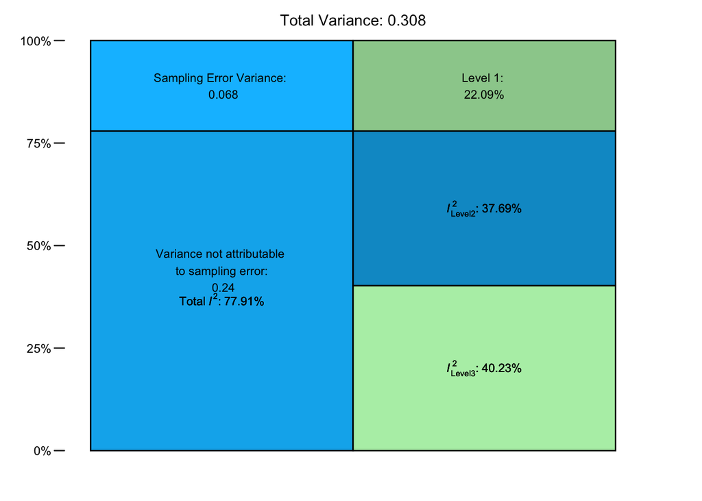

```r
# Extract the variance components
res <- dmetar::var.comp(REM3st)
plot(res)
```

```r
# Estimation of overall and level-specific I-squared
X2 <- model.matrix(REM3st)
P2 <- W - W %*% X2 %*% solve(t(X2) %*% W %*% X2) %*% t(X2) %*% W
# Overall I-squared
100 * sum(REM3st$sigma2) / (sum(REM3st$sigma2) + (REM3st$k-REM3st$p)/sum(diag(P2)))
```

```
## [1] 77.91398
```

```r
# I-squared by level
100 * REM3st$sigma2 / (sum(REM3st$sigma2) + (REM3st$k-REM3st$p)/sum(diag(P2)))
```

```
## [1] 40.22591 37.68807
```

```r
# Profile plots
# Creating these plots took about 10 minutes.
#profile.rma.mv(REM3st, sigma2=1)
#profile.rma.mv(REM3st, sigma2=2)

# ICCs
round(REM3st$sigma2[1] / sum(REM3st$sigma2), 3)
```

```
## [1] 0.516
```

```r
round(REM3st$sigma2[2] / sum(REM3st$sigma2), 3)
```

```
## [1] 0.484
```

### Four-level random-effects model with between-sample and between-study variance

```r
# Model estimation
REM3sast <- rma.mv(g,
                   vg,
                   data = lehtonen18,
                   method = "REML",
                   tdist = TRUE,
                   test = "t",
                   random = list(~ 1 | StudyID/SampleID/ESID))

# Summary of the results
summary(REM3sast)
```

```
##
## Multivariate Meta-Analysis Model (k = 891; method: REML)
##
##    logLik   Deviance        AIC        BIC       AICc
## -693.8499  1387.6998  1395.6998  1414.8647  1395.7450
##
## Variance Components:
##
##             estim    sqrt  nlvls  fixed                 factor
## sigma^2.1  0.1116  0.3341    152     no                StudyID
## sigma^2.2  0.0178  0.1335    273     no       StudyID/SampleID
## sigma^2.3  0.1078  0.3283    891     no  StudyID/SampleID/ESID
##
## Test for Heterogeneity:
## Q(df = 890) = 3239.5972, p-val < .0001
##
## Model Results:
##
## estimate      se    tval   df    pval   ci.lb   ci.ub
##   0.0778  0.0340  2.2870  890  0.0224  0.0110  0.1446  *
##
## ---
## Signif. codes:  0 '***' 0.001 '**' 0.01 '*' 0.05 '.' 0.1 ' ' 1
```

```r
# Cluster-robust standard errors
coef_test(REM3sast, vcov = "CR2")
```

```
##    Coef. Estimate    SE t-stat d.f. (Satt) p-val (Satt) Sig.
##  intrcpt   0.0778 0.034   2.29         141       0.0237    *
```

```r
## Level-specific heterogeneity
X3 <- model.matrix(REM3sast)
P3 <- W - W %*% X3 %*% solve(t(X3) %*% W %*% X3) %*% t(X3) %*% W
# Overall I-squared
100 * sum(REM3sast$sigma2) / (sum(REM3sast$sigma2) + (REM3sast$k-REM3sast$p)/sum(diag(P3)))
```

```
## [1] 77.74022
```

```r
# I-squared by level
100 * REM3sast$sigma2 / (sum(REM3sast$sigma2) + (REM3sast$k-REM3sast$p)/sum(diag(P3)))
```

```
## [1] 36.577629  5.840586 35.322008
```

### Cross-classified random-effects model with between-study and between-task variance

This model represents a cross-classified random-effects model (CCREM).

```r
# Model estimation
CCREM <- rma.mv(g,
                vg,
                data = lehtonen18,
                method = "REML",
                tdist = TRUE,
                test = "t",
                random = list(~ 1 | StudyID/ESID,
                              ~ 1 | TaskID))

# Summary of the results
summary(CCREM)
```

```
##
## Multivariate Meta-Analysis Model (k = 891; method: REML)
##
##    logLik   Deviance        AIC        BIC       AICc
## -680.0790  1360.1580  1368.1580  1387.3229  1368.2032
##
## Variance Components:
##
##             estim    sqrt  nlvls  fixed        factor
## sigma^2.1  0.1315  0.3627    152     no       StudyID
## sigma^2.2  0.1007  0.3173    891     no  StudyID/ESID
## sigma^2.3  0.0251  0.1584     30     no        TaskID
##
## Test for Heterogeneity:
## Q(df = 890) = 3239.5972, p-val < .0001
##
## Model Results:
##
## estimate      se    tval   df    pval    ci.lb   ci.ub
##   0.0598  0.0513  1.1648  890  0.2444  -0.0410  0.1606
##
## ---
## Signif. codes:  0 '***' 0.001 '**' 0.01 '*' 0.05 '.' 0.1 ' ' 1
```

```r
# Confidence intervals
#confint(CCREM, digits = 4)

## Level-specific heterogeneity
X4 <- model.matrix(CCREM)
P4 <- W - W %*% X4 %*% solve(t(X4) %*% W %*% X4) %*% t(X4) %*% W
# Overall I-squared
100 * sum(CCREM$sigma2) / (sum(CCREM$sigma2) + (CCREM$k-CCREM$p)/sum(diag(P4)))
```

```
## [1] 79.10968
```

```r
# I-squared by level
100 * CCREM$sigma2 / (sum(CCREM$sigma2) + (CCREM$k-CCREM$p)/sum(diag(P4)))
```

```
## [1] 40.44098 30.95132  7.71739
```

### Model selection

To select a baseline model among the multilevel models, we compare them using likelihood-ratio tests and information criteria.

```r
## Standard REM vs. three-level REM
anova(REM2, REM3st)
```

```
##
##         df       AIC       BIC      AICc    logLik      LRT   pval        QE
## Full     3 1398.3678 1412.7415 1398.3949 -696.1839                 3239.5972
## Reduced  2 1564.3472 1573.9297 1564.3608 -780.1736 167.9794 <.0001 3239.5972
```

```r
## Result: Significant improvement of model fit when allowing
## for within- and between-study heterogeneity.
## Model REM3st wins on all criteria.

## Three-level REM vs. Four-level REM
anova(REM3st, REM3sast)
```

```
##
##         df       AIC       BIC      AICc    logLik    LRT   pval        QE
## Full     4 1395.6998 1414.8647 1395.7450 -693.8499               3239.5972
## Reduced  3 1398.3678 1412.7415 1398.3949 -696.1839 4.6680 0.0307 3239.5972
```

```r
## No consistent evidence on improvement of model fit.
## Conclusion: Use the more parsimonious model for later tests.

## Three-level REM vs. cross-classified REM
anova(REM3st, CCREM)
```

```
##
##         df       AIC       BIC      AICc    logLik     LRT   pval        QE
## Full     4 1368.1580 1387.3229 1368.2032 -680.0790                3239.5972
## Reduced  3 1398.3678 1412.7415 1398.3949 -696.1839 32.2098 <.0001 3239.5972
```

```r
## Result: Clear improvement of model fit when adding heterogeneity
## across tasks.
## Model CCREM fits better on all criteria.
```

Given these model comparisons, we could select model `CCREM` as the meta-analytic baseline model.

### Moderator analyses

This model represents a cross-classified mixed-effects meta-regression model (CCMEM).

```r
# Model estimation
CCMEM <- rma.mv(g,
                vg,
                data = lehtonen18,
                method = "REML",
                tdist = TRUE,
                test = "t",
                random = list(~ 1 | StudyID/ESID,
                              ~ 1 | TaskID),
                mods = ~ Stimulus.binary + StudyType.binary)

# Summary of the results
summary(CCMEM)
```

```
##
## Multivariate Meta-Analysis Model (k = 891; method: REML)
##
##    logLik   Deviance        AIC        BIC       AICc
## -671.0600  1342.1201  1354.1201  1382.8539  1354.2154
##
## Variance Components:
##
##             estim    sqrt  nlvls  fixed        factor
## sigma^2.1  0.1284  0.3583    152     no       StudyID
## sigma^2.2  0.0981  0.3132    891     no  StudyID/ESID
## sigma^2.3  0.0215  0.1467     30     no        TaskID
##
## Test for Residual Heterogeneity:
## QE(df = 888) = 3150.1797, p-val < .0001
##
## Test of Moderators (coefficients 2:3):
## F(df1 = 2, df2 = 888) = 7.6335, p-val = 0.0005
##
## Model Results:
##
##                   estimate      se     tval   df    pval    ci.lb    ci.ub
## intrcpt             0.1139  0.0756   1.5077  888  0.1320  -0.0344   0.2622
## Stimulus.binary    -0.1725  0.0454  -3.7994  888  0.0002  -0.2616  -0.0834  ***
## StudyType.binary    0.0652  0.0742   0.8787  888  0.3798  -0.0804   0.2109
##
## ---
## Signif. codes:  0 '***' 0.001 '**' 0.01 '*' 0.05 '.' 0.1 ' ' 1
```

```r
# Variance explanations
# Reduction of variances when comparing the models without and with moderators (R-squared)

# Between-study variance explanation
max((CCREM$sigma2[1]-CCMEM$sigma2[1])/CCREM$sigma2[1], 0)
```

```
## [1] 0.02370672
```

```r
## Result: about 2.4 %

# Within-study between-effects variance explanation
max((CCREM$sigma2[2]-CCMEM$sigma2[2])/CCREM$sigma2[2], 0)
```

```
## [1] 0.02530506
```

```r
## Result: about 2.5 %

# Between-task variance explanation
max((CCREM$sigma2[3]-CCMEM$sigma2[3])/CCREM$sigma2[3], 0)
```

```
## [1] 0.1430961
```

```r
## Result: about 14.3 %
```

## Multilevel meta-analysis with correlated effects (MLMA-CE)

### Baseline model: Hierarchical and correlated effects

```r
## Source code: Pustejovsky & Tipton (2021)
## https://doi.org/10.31222/osf.io/vyfcj

## Make a reasoned assumption on the correlations between effects.
## Task are correlated within studies.
## We provide a constant sampling correlation (csc).
rho <- 0.5

## Define the sampling variance-covariance matrix per study
V_mat <- metafor::vcalc(lehtonen18$vg,
                        cluster = lehtonen18$StudyID,
                        rho = rho,
                        checkpd = TRUE,
                        nearpd = TRUE)


## Estimate the full model of the meta-analysis with three levels
REM3L.csc <- rma.mv(g,
                    V = V_mat,
                    random = list(~ 1 | StudyID/ESID),
                    data = lehtonen18,
                    method = "REML",
                    tdist = TRUE,
                    test = "t")

## Summarize the results
summary(REM3L.csc, digits=4)
```

```
##
## Multivariate Meta-Analysis Model (k = 891; method: REML)
##
##    logLik   Deviance        AIC        BIC       AICc
## -701.9632  1403.9263  1409.9263  1424.3000  1409.9534
##
## Variance Components:
##
##             estim    sqrt  nlvls  fixed        factor
## sigma^2.1  0.0315  0.1775    152     no       StudyID
## sigma^2.2  0.2179  0.4668    891     no  StudyID/ESID
##
## Test for Heterogeneity:
## Q(df = 890) = 27400504814.6733, p-val < .0001
##
## Model Results:
##
## estimate      se    tval   df    pval    ci.lb   ci.ub
##   0.0253  0.0329  0.7687  890  0.4423  -0.0393  0.0899
##
## ---
## Signif. codes:  0 '***' 0.001 '**' 0.01 '*' 0.05 '.' 0.1 ' ' 1
```

```r
# Call for the 95% confidence intervals
# confint(REM3L.csc, digits=4)

## RVE standard errors
conf_int(REM3L.csc, vcov = "CR2")
```

```
##    Coef. Estimate     SE d.f. Lower 95% CI Upper 95% CI
##  intrcpt   0.0253 0.0329  131      -0.0398       0.0904
```

### Mixed-effects meta-regression model: Hierarchical and correlated effects

```r
## Estimate the full model of the meta-analysis with three levels
MEM3L.csc <- rma.mv(g,
                    V = V_mat,
                    random = list(~ 1 | StudyID/ESID),
                    data = lehtonen18,
                    method = "REML",
                    tdist = TRUE,
                    test = "t",
                    mods = ~ Stimulus.binary + StudyType.binary)

## Summarize the results
summary(MEM3L.csc, digits=4)
```

```
##
## Multivariate Meta-Analysis Model (k = 891; method: REML)
##
##    logLik   Deviance        AIC        BIC       AICc
## -746.5437  1493.0874  1503.0874  1527.0322  1503.1554
##
## Variance Components:
##
##             estim    sqrt  nlvls  fixed        factor
## sigma^2.1  0.0824  0.2870    152     no       StudyID
## sigma^2.2  0.1801  0.4244    891     no  StudyID/ESID
##
## Test for Residual Heterogeneity:
## QE(df = 888) = 4112.3027, p-val < .0001
##
## Test of Moderators (coefficients 2:3):
## F(df1 = 2, df2 = 888) = 11.4250, p-val < .0001
##
## Model Results:
##
##                   estimate      se     tval   df    pval    ci.lb    ci.ub
## intrcpt             0.1093  0.0635   1.7198  888  0.0858  -0.0154   0.2340    .
## Stimulus.binary    -0.1847  0.0396  -4.6679  888  <.0001  -0.2624  -0.1071  ***
## StudyType.binary    0.0834  0.0735   1.1354  888  0.2565  -0.0608   0.2276
##
## ---
## Signif. codes:  0 '***' 0.001 '**' 0.01 '*' 0.05 '.' 0.1 ' ' 1
```

```r
## RVE standard errors
conf_int(MEM3L.csc, vcov = "CR2")
```

```
##             Coef. Estimate     SE d.f. Lower 95% CI Upper 95% CI
##           intrcpt   0.1093 0.0718 46.0      -0.0353       0.2539
##   Stimulus.binary  -0.1847 0.0567 62.0      -0.2981      -0.0714
##  StudyType.binary   0.0834 0.0794 82.9      -0.0745       0.2413
```